# Introduction to Neural Networks: Bank Churn prediction

### Observations

**Loss function**

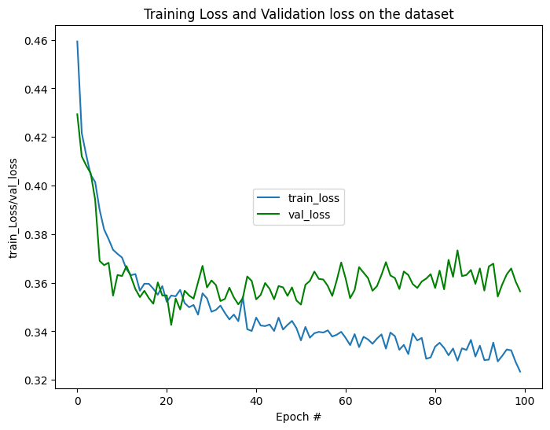

```python
N =100
plt.figure(figsize=(8,6))
plt.plot(np.arange(0, N), history_h.history["loss"], label="train_loss")
plt.plot(np.arange(0, N), history_h.history["val_loss"], color='green', label="val_loss")

plt.title("Training Loss and Validation loss on the dataset")
plt.xlabel("Epoch #")
plt.ylabel("train_Loss/val_loss")
plt.legend(loc="center")
plt.show()
```

### Observations

- The visual representation depicted in the graph provides a clear insight into the model's learning dynamics over the course of multiple epochs. Initially, up to around 40 epochs, there is a discernible decrease in the loss function values for both the training and validation datasets. This convergence suggests that the model is effectively learning from the training data, minimizing discrepancies between predicted and actual values. However, beyond this point, a noticeable divergence occurs between the loss trends of the training and validation datasets, indicating the onset of overfitting. In other words, the model starts to excessively tailor its parameters to the training data, losing its ability to generalize well to new, unseen data. This divergence in loss trends beyond approximately 40 epochs serves as a critical point of observation, emphasizing the need for effective regularization techniques to mitigate overfitting and enhance the model's generalization capabilities.

**Threshold**

```
Best Threshold=0.250852, G-Mean=0.817
```

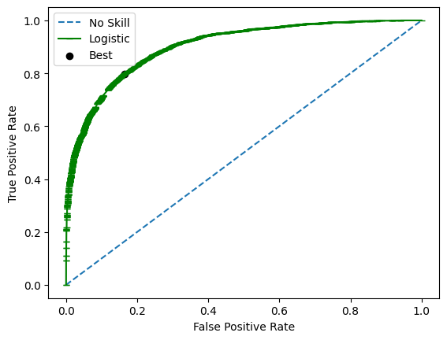

```python
# Predicting probabilities
yhat = estimator_v2.predict(X_train)
# keeping probabilities for the positive outcome only
yhat = yhat[:, 0]
# calculating roc curves
fpr, tpr, thresholds = roc_curve(y_train, yhat)
# calculating the g-mean for each threshold
gmeans = np.sqrt(tpr * (1-fpr))
# locating the index of the largest g-mean
ix = np.argmax(gmeans)
print('Best Threshold=%f, G-Mean=%.3f' % (thresholds[ix], gmeans[ix]))
# plotting the roc curve for the model
pyplot.plot([0,1], [0,1], linestyle='--', label='No Skill')
pyplot.plot(fpr, tpr, marker='_', color='green', label='Logistic')
pyplot.scatter(fpr[ix], tpr[ix], marker='o',  color='black', label='Best')
# axis labels
pyplot.xlabel('False Positive Rate')
pyplot.ylabel('True Positive Rate')
pyplot.legend()
# showing the plot
pyplot.show()
```

### Observations

**Predict the results using the best threshold**

```python
# Obtaining the predictions on X_val
y_pred_h = estimator_v2.predict(X_val)
print(y_pred_h)
```

```
[[0.1149441 ]
 [0.0057838 ]
 [0.03616453]
 ...
 [0.17271231]
 [0.43125156]
 [0.47276238]]
```

```python
# To use the confusion Matrix, the probabilities that a customer will leave the bank are converted into the form true or false.
# So a cutoff value is used to indicate whether they are likely to exit or not.
y_pred_h = (y_pred_h > thresholds[ix])
print(y_pred_h)
```

```
[[False]
 [False]
 [False]
 ...
 [False]
 [ True]
 [ True]]
```

**Classification report**

```python
# Obtain the classification report
cr=metrics.classification_report(y_val,y_pred_h)
print(cr)
```

```
              precision    recall  f1-score   support

           0       0.93      0.79      0.85      1274
           1       0.48      0.77      0.59       326

    accuracy                           0.79      1600
   macro avg       0.71      0.78      0.72      1600
weighted avg       0.84      0.79      0.80      1600
```

### Observations

- The model's precision exhibits a notable strength for class 0, reflecting its proficiency in accurately identifying instances belonging to this category. However, when it comes to class 1, the precision is comparatively lower, indicating that the model may be more conservative in predicting positive instances for this class. On the recall front, the model demonstrates commendable performance for both classes, showcasing its ability to capture a significant portion of true positive instances. The F1-scores, derived from the harmonic mean of precision and recall, contribute to a well-rounded evaluation, offering insights into the model's overall effectiveness.
- Macro and weighted averages further enrich the understanding of the model's performance by calculating the average precision, recall, and F1-score for both classes. These averages provide a comprehensive summary, capturing the model's performance across various metrics. Notably, the recall metrics exhibit improvement when compared to the previous model that underwent hyperparameter tuning, indicating that the careful adjustment of hyperparameters has positively influenced the model's ability to capture instances from both classes. This enhancement in recall underscores the effectiveness of hyperparameter tuning in refining the model's predictive capabilities and overall performance.

**Confusion matrix**

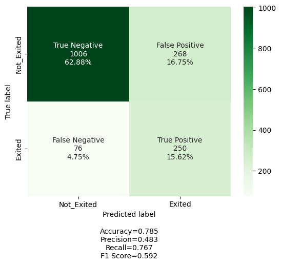

```python
## Complete the code to obtain the confusion matrix
cm_h=confusion_matrix(y_val, y_pred_h)

labels = ['True Negative','False Positive','False Negative','True Positive']
categories = [ 'Not_Exited','Exited']
make_confusion_matrix(cm_h,
                      group_names=labels,
                      categories=categories,
                      cmap='Greens')
```

### Observations

- The model is deliberately designed with a primary focus on maximizing recall, aiming to capture a higher proportion of true positive instances, especially crucial in scenarios where the cost of missing positive cases is significant. This strategic emphasis on recall results in a well-considered trade-off between precision and recall, culminating in an overall balanced performance. By achieving a harmonious equilibrium between the ability to correctly identify positive instances and the precision of those identifications, the model proves its effectiveness across a diverse set of predictions.
- Notably, the recall achieved by this model surpasses that of its predecessors. This improvement underscores the success of the model's tailored approach toward prioritizing recall, indicating a refined and more robust ability to identify positive instances accurately. The model's enhanced recall contributes to its overall effectiveness and underscores the success of its optimization for capturing a broader range of true positive instances.

### Model Improvement: Neural Network model with balanced data

**Applying SMOTE to balance this dataset and then again apply hyperparamter tuning accordingly.**

```python
## Apply SMOTE on train data
sm  = SMOTE(random_state=42)
X_train, y_train = sm.fit_resample(X_train,y_train)
print('After UpSampling, the shape of train_X: {}'.format(X_train.shape))
print('After UpSampling, the shape of train_y: {} \n'.format(y_train.shape))
```

```
After UpSampling, the shape of train_X: (10192, 11)
After UpSampling, the shape of train_y: (10192, 1)
```

[figure not shown]

```python
sns.countplot(y_train['Exited'], color='green')
```

**Build a model with the balanced dataset**

```python
backend.clear_session()
#Fixing the seed for random number generators so that we can ensure we receive the same output everytime
np.random.seed(2)
random.seed(2)
tf.random.set_seed(2)
```

```python
## Initilaize a sequential model
model_4 = Sequential()

# Add a input layer of 32 neurons with relu as activation function
model_4.add(Dense(32,activation='relu',input_dim = X_train.shape[1]))

# Add dropout with dropout rate=0.2
model_4.add(Dropout(0.2))
# Adding hidden layer with 16 neurons with relu as activation function
model_4.add(Dense(16,activation='relu'))

# Adding the dropout
model_4.add(Dropout(0.1))

## Add dense layers with 8 neurons
model_4.add(Dense(8,activation='relu'))

# Add suitable activation function in the final layer
model_4.add(Dense(1, activation = 'sigmoid'))
```

```python
## Complete the code to obtain the summary of the model
model_4.summary()
```

```
Model: "sequential"
_________________________________________________________________
 Layer (type)                Output Shape              Param #
=================================================================
 dense (Dense)               (None, 32)                384

 dropout (Dropout)           (None, 32)                0

 dense_1 (Dense)             (None, 16)                528

 dropout_1 (Dropout)         (None, 16)                0

 dense_2 (Dense)             (None, 8)                 136

 dense_3 (Dense)             (None, 1)                 9

=================================================================
Total params: 1,057
Trainable params: 1,057
Non-trainable params: 0
_________________________________________________________________
```

### Observations

- The architecture at hand is structured as a sequential neural network, comprising multiple dense layers interposed with strategically placed dropout layers. These dropout layers, designed to mitigate overfitting by randomly deactivating a fraction of input units during training, contribute to the model's overall adaptability and generalization. In terms of size, the entire network encompasses a total of 1,057 parameters, which collectively represent the weights and biases within the neural network. This parameter count serves as a key indicator of the model's complexity and the number of parameters that the model fine-tunes during the training process. With 1,057 parameters, the model is categorized as relatively small-sized, emphasizing a balance between capturing intricate patterns in the data and avoiding unnecessary complexity. This design choice reflects a deliberate effort to create a streamlined yet effective neural network for the given task.

```python
# Define earlystopping as callback
es_cb = callbacks.EarlyStopping(monitor='val_loss', min_delta=0.001, patience=5)

# Initializing Adam optimizer
optimizer = tf.keras.optimizers.Adam(0.001)

# Complining the model with binary cross entropy as loss and accuracy as metrics
model_4.compile(optimizer = optimizer,loss = 'binary_crossentropy', metrics = ['accuracy'])

# Fit the model on train with batch_size of 64, epochs of 100 and callbacks as earlystopping
history_4 = model_4.fit(X_train,y_train,batch_size=64,epochs=100,verbose=1,validation_data = (X_val,y_val),callbacks=[es_cb])
```

### Observations

**Loss function**

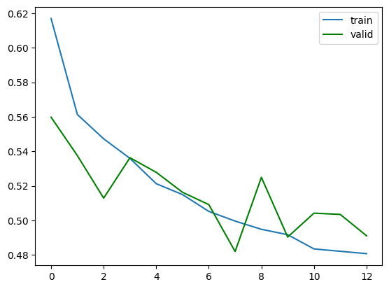

```python
# Capturing learning history per epoch
hist  = pd.DataFrame(history_4.history)
hist['epoch'] = history_4.epoch

# Plotting accuracy at different epochs
plt.plot(hist['loss'])
plt.plot(hist['val_loss'], color='green')
plt.legend(("train" , "valid") , loc =0)
```

### Observations

The training and validation losses are decreasing; however, there are significant fluctuations in the validation losses.

**Finding the optimal threshold**

```
Best Threshold=0.486954, G-Mean=0.795
```

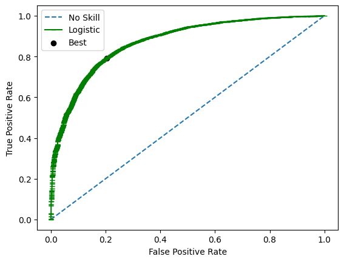

```python
# Finding the optimal threshold using X_train
yhat = model_4.predict(X_train)

# keeping probabilities for the positive outcome only
yhat = yhat[:, 0]
# calculating roc curves
fpr, tpr, thresholds = roc_curve(y_train, yhat)
# calculating the g-mean for each threshold
gmeans = np.sqrt(tpr * (1-fpr))
# locating the index of the largest g-mean
ix = np.argmax(gmeans)
print('Best Threshold=%f, G-Mean=%.3f' % (thresholds[ix], gmeans[ix]))
# plotting the roc curve for the model
pyplot.plot([0,1], [0,1], linestyle='--', label='No Skill')
pyplot.plot(fpr, tpr, marker='_', color='green', label='Logistic')
pyplot.scatter(fpr[ix], tpr[ix], marker='o', color='black', label='Best')
# axis labels
pyplot.xlabel('False Positive Rate')
pyplot.ylabel('True Positive Rate')
pyplot.legend()
# showing the plot
pyplot.show()
```

### Observations

The output suggests that, based on ROC-AUC analysis, the model's optimal threshold is determined to be 0.486954, and at this threshold, the G-Mean is 0.795. This threshold is selected to optimize the model's overall performance, considering both positive and negative class predictions.

```python
## Obtain the predictions on X_val
y_pred_s = model_4.predict(X_val)
# Predicting the results using tuned threshold
y_pred_s = (y_pred_s >thresholds[ix])
y_pred_s
```

```
array([[False],
       [False],
       [False],
       ...,
       [False],
       [ True],
       [ True]])
```

**Classification report**

```python
cr=metrics.classification_report(y_val,y_pred_s)
print(cr)
```

```
              precision    recall  f1-score   support

           0       0.90      0.78      0.83      1274
           1       0.43      0.66      0.52       326

    accuracy                           0.75      1600
   macro avg       0.67      0.72      0.68      1600
weighted avg       0.80      0.75      0.77      1600
```

### Observations

The model demonstrates strong precision for class 0 but lower precision for class 1. It has good recall for both classes, and the F1-scores provide a balanced evaluation. The macro and weighted averages give a comprehensive summary of the overall model performance. Overall, there has been a decline in recall compared to the previous models.

**Confusion matrix**

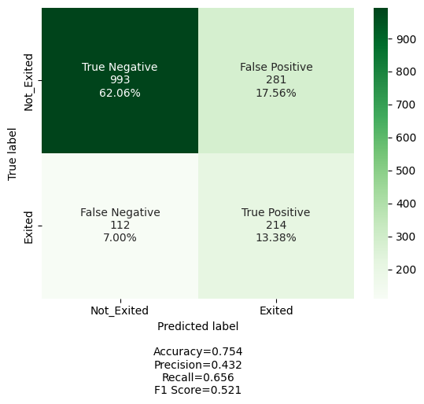

```python
#Calculating the confusion matrix
cm_s=confusion_matrix(y_val, y_pred_s)
labels = ['True Negative','False Positive','False Negative','True Positive']
categories = [ 'Not_Exited','Exited']
make_confusion_matrix(cm_s,
                      group_names=labels,
                      categories=categories,
                      cmap='Greens')
```

### Observations

The model, with a focus on maximizing recall, shows a reasonable trade-off between precision and recall, however, there has been a decline in recall compared to the previous models.

## Final Model

In general, upon comparing the loss function plots for the training and validation datasets, it appears that Model 3 is the most optimal model.

```
Best Threshold=0.197877, G-Mean=0.810
```

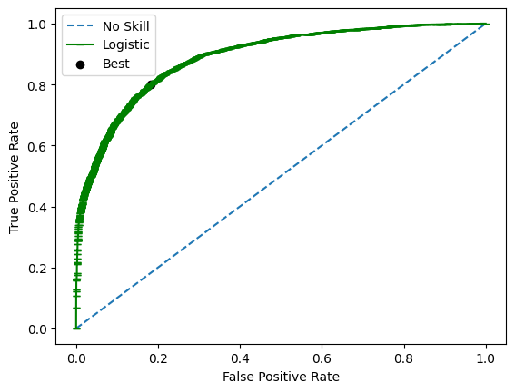

```python
# predicting probabilities using the best model
yhat = model_3.predict(X_train)
# keeping probabilities for the positive outcome only
yhat = yhat[:, 0]
# calculating roc curves
fpr, tpr, thresholds = roc_curve(y_train, yhat)
# calculating the g-mean for each threshold
gmeans = np.sqrt(tpr * (1-fpr))
# locating the index of the largest g-mean
ix = np.argmax(gmeans)
print('Best Threshold=%f, G-Mean=%.3f' % (thresholds[ix], gmeans[ix]))
# plotting the roc curve for the model
pyplot.plot([0,1], [0,1], linestyle='--', label='No Skill')
pyplot.plot(fpr, tpr, marker='_', color='green', label='Logistic')
pyplot.scatter(fpr[ix], tpr[ix], marker='o', color='black', label='Best')
# axis labels
pyplot.xlabel('False Positive Rate')
pyplot.ylabel('True Positive Rate')
pyplot.legend()
# showing the plot
pyplot.show()
```

### Observations

The output suggests that, based on ROC-AUC analysis and running for 319 epochs, the best model's optimal threshold is determined to be 0.197877, and at this threshold, the G-Mean is 0.810.

```python
# Predict the X_test data using the best model
y_pred_test = model_3.predict(X_test)
y_pred_test = (y_pred_test > thresholds[ix])
print(y_pred_test)
```

```
[[False]
 [False]
 [False]
 ...
 [ True]
 [False]
 [False]]
```

**Classification report**

```python
## Obtain the classification report on y_test and the predicted values
cr=metrics.classification_report(y_test,y_pred_test)
print(cr)
```

```
              precision    recall  f1-score   support

           0       0.93      0.80      0.86      1593
           1       0.50      0.75      0.60       407

    accuracy                           0.79      2000
   macro avg       0.71      0.78      0.73      2000
weighted avg       0.84      0.79      0.81      2000
```

The best model classification report on the test dataset demonstrates high precision for class 0 and moderate precision for class 1. It has good recall for both classes, and the F1-scores provide a balanced evaluation. The macro and weighted averages give a comprehensive summary of the overall model performance.

**Confusion report**

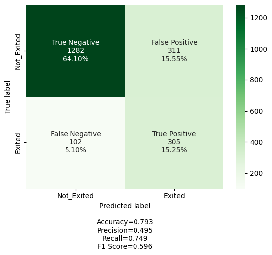

```python
# Obtain the confusion matrix
cm_h=confusion_matrix(y_test,y_pred_test)
labels = ['True Negative','False Positive','False Negative','True Positive']
categories = [ 'Not_Exited','Exited']
make_confusion_matrix(cm_h,
                      group_names=labels,
                      categories=categories,
                      cmap='Greens')
```

### Observations

- The evaluation of the model's performance on the test data, with a specific emphasis on maximizing recall, reveals a commendable outcome. The model demonstrates a reasonably high recall, indicating its effectiveness in correctly identifying a substantial portion of positive instances within the test dataset. This focus on recall is particularly important in scenarios where the consequence of missing positive cases is significant.
- Additionally, the evaluation underscores a discernible trade-off between precision and recall, emphasizing the model's capability to strike a balance between these two metrics. Achieving this balance is crucial as it ensures that the model not only identifies positive instances accurately but also minimizes the instances where it incorrectly labels negatives as positives. This nuanced trade-off is indicative of the model's thoughtful optimization for a diverse set of predictions, showcasing its adaptability to different scenarios and contributing to an overall well-rounded performance on the test data.

## Actionable Insights and Business Recommendations

**What recommedations would you suggest to the bank?**

- The best model, prioritizing recall, displays reasonably good recall and achieves a balanced trade-off between precision and recall, resulting in an overall strong and balanced performance.
- On the test dataset, the best model exhibits strong precision (0.93) for not churned and reasonable precision (0.50) for churned, performing well in recall (0.80) for not churned but with relatively lower recall (0.75) for churned.
- The best model's performance on the validation dataset demonstrates strong precision (0.92) for not churned and reasonable precision (0.51) for churned, with good recall (0.82) for not churned and relatively lower recall (0.74) for churned.
- A visual representation of the loss function for the model illustrates a consistent decrease in both training and validation loss with increasing epochs, indicating robust generalization without evident signs of overfitting or underfitting.
- Among various model-building strategies, Model 3, a Neural Network model with Dropout, is recommended as the optimal choice for the bank's objectives.
- The development of a robust predictive model is deemed crucial for the bank, particularly in scenarios where the model falsely predicts that a customer is not exiting when they actually are. To address potential risks and prevent oversight of sensitive customer issues, the bank should prioritize the reduction of False Negatives, emphasizing a higher Recall metric.
- Seventy-five percent of churned customers maintain balances between 50,000 and 130,000, indicating that customers with balances below 50,000 are less likely to churn. The bank should identify and incentivize customers with balances between 50,000 and 130,000 through offers and promotions.
- An analysis of the stacked bar plot reveals a higher churn rate among inactive customers compared to active ones, suggesting an opportunity for the bank to identify and re-engage inactive customers through targeted promotions.
- The analysis of Gender and Exits reveals a significant discrepancy in churn rates, with females experiencing a higher rate at 25%, compared to males at 16%. This prompts the recommendation for tailored strategies, such as increasing the recruitment of female customer service representatives and implementing promotions to incentivize female customers. Similarly, the examination of Geography and Exits indicates that Germany has the highest churn rate at nearly 32%, followed by France and Spain, both at around 16%. Considering France's substantial customer base and Germany and Spain falling within the 25% range, the suggestion is to focus on customers in Germany and France through targeted promotions. Furthermore, a moderate positive correlation of 0.29 between Age and customer exits is identified, with 75% of churned customers falling within the age range of 39 to 51. To address this demographic, the recommendation is to direct efforts toward this age group with additional support, promotions, and discounts.